# graphs_v3

## Graph 5: Insitutional corruption and reported crime by state

One of the main issues that fosters the high levels of violence is the fact that people do not trust the justice institutions and do not report crimes. Nevertheless, the graph shows how people report crimes even though thtey percieve their institutions to be corrupt. However, there are states (in red) like Baja Califorina, Guanajuatio, Jalisco, Puebla, and the State of Mexico that do not fit the overall trend by the rest of the states.

```r
incidencia <- (read_csv("denunciados_incidencia.csv"))
```

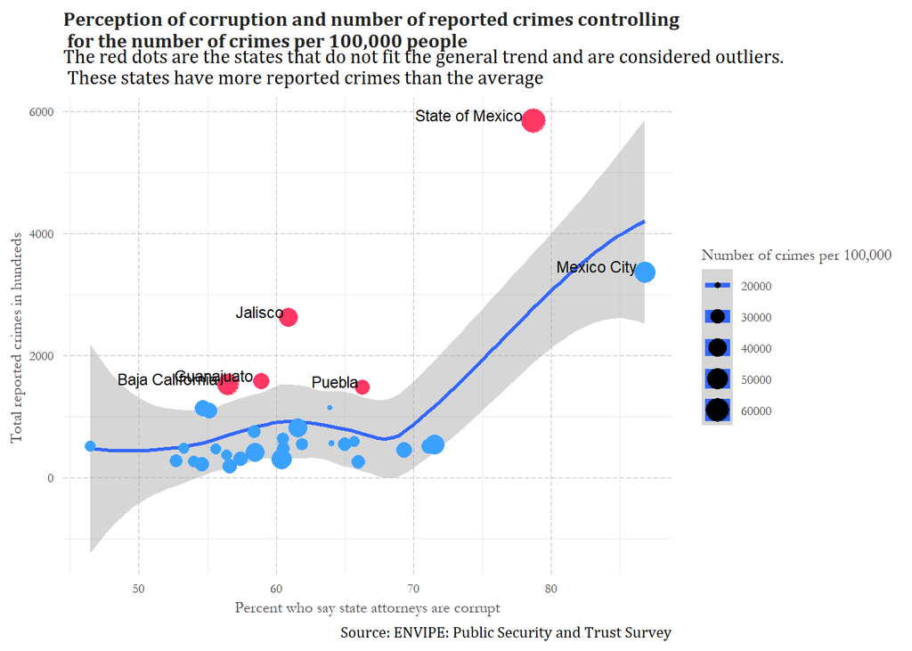

```r
ggplot(incidencia, aes(x= corrupcion_mp, y = delitos_denunciados/100, size = Incidencia_delicitva_tasa_2017, label = State)) +
  geom_smooth() +
  geom_point(color = ifelse(incidencia$delitos_denunciados > 120005 & incidencia$corrupcion_mp < 80, "#ff3864", "#3ba1ff")) +
  labs(x = "Percent who say state attorneys are corrupt", y = "Total reported crimes in hundreds ", subtitle = "The red dots are the states that do not fit the general trend and are considered outliers. \n These states have more reported crimes than the average", caption = "Source: ENVIPE: Public Security and Trust Survey", size = "Number of crimes per 100,000") +
  ggtitle("Perception of corruption and number of reported crimes controlling \n for the number of crimes per 100,000 people") +
  geom_text(aes(label=ifelse(delitos_denunciados>120005,as.character(State),'')),hjust=1.1,vjust=0,size=3)+
  theme_mmh()
```

## Graph 6: Cause of homicide by sex

The human side of homicides show how there are different dynamics between men a women. The way men and women are killed show different patterns that may point to different phenomena. Women, unlike men are killed by asphyxiation and knife that point towards the high levels of feminicides in the country. Men on the other hand are killed mostly by firearm that point towards the deaths involved in the war of drugs.

```r
causegraph <- read.csv("causegraph.csv")
```

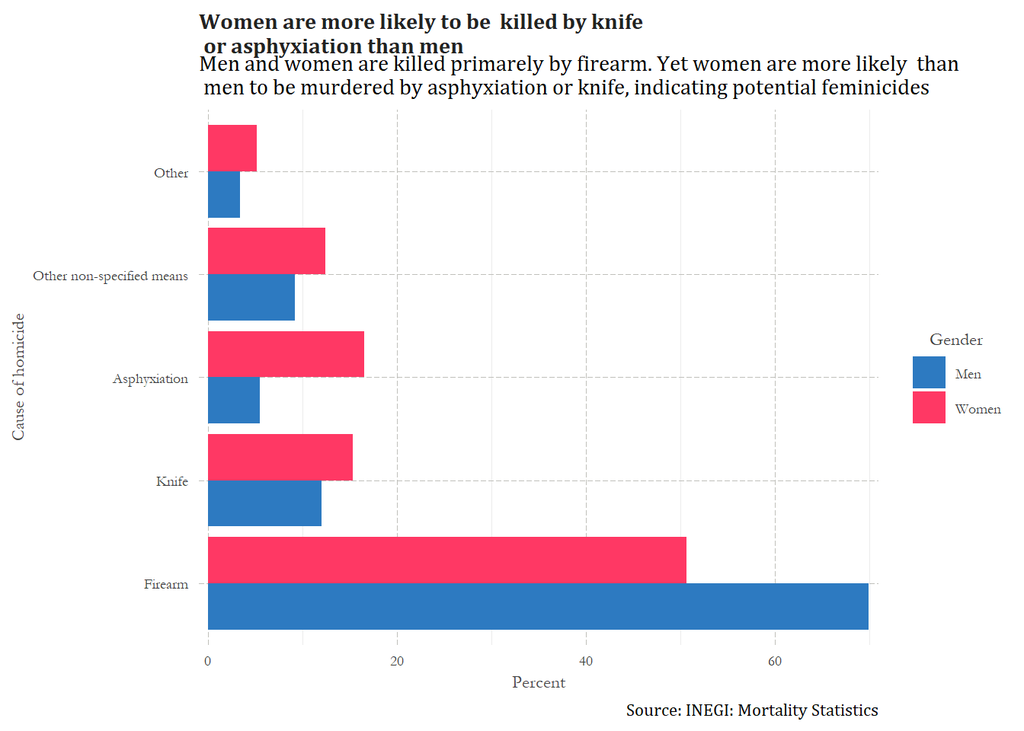

```r
ggplot(causegraph) +
geom_bar(mapping = aes(x = reorder(cause3, -percent), y = percent, group = sexo2, fill = factor(sexo2)),stat = "identity", position = "dodge")+ coord_flip() +
  scale_y_continuous(expand = c(0,1))+
  scale_fill_manual ("Gender", values = c("Men" = "#2d7ac1", "Women" = "#ff3864")) +
  labs(x = "Cause of homicide", y = "Percent", subtitle = "Men and women are killed primarely by firearm. Yet women are more likely  than \n men to be murdered by asphyxiation or knife, indicating potential feminicides", caption = "Source: INEGI: Mortality Statistics") +
  ggtitle("Women are more likely to be  killed by knife \n or asphyxiation than men") +
  guides(fill=guide_legend("Gender")) +
  theme_mmh()
```

## Graph 7: Place of homicide and relationship to killer

```r
sankey <- read_csv("sankey_graph_v2.csv")
```

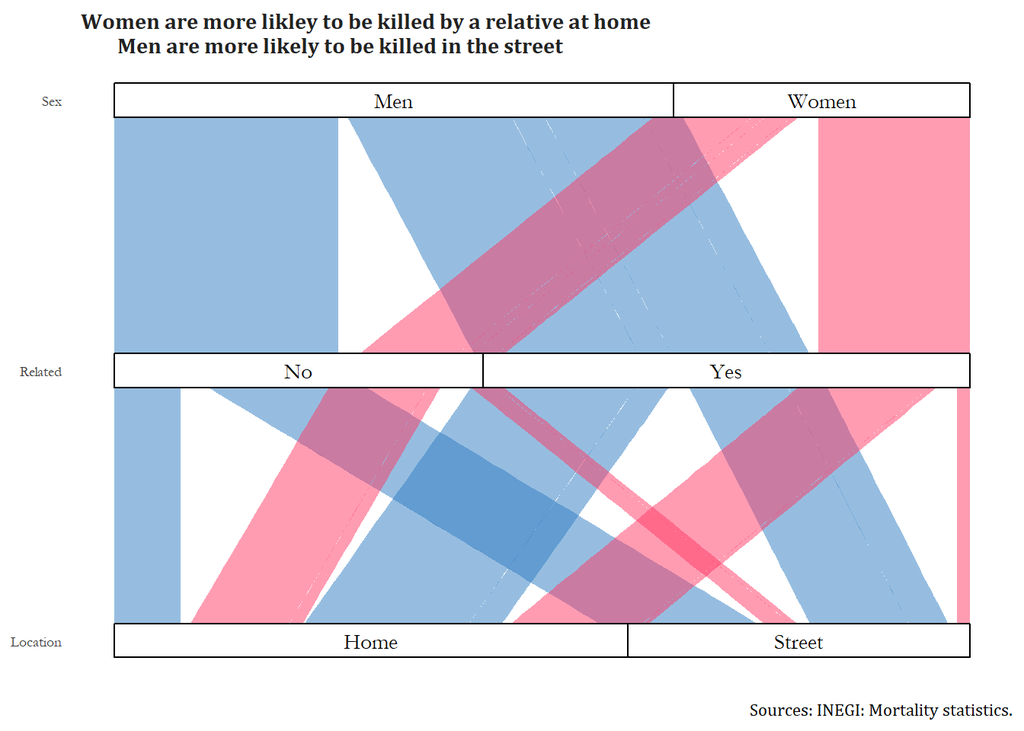

```r
colors <- c("#2d7ac1", "#ff3864", "#ccc9b3")
ggplot(sankey,
       aes(y = freq,
          axis1 = location, axis2 = related, axis3 = sexo)) +
  geom_alluvium(aes(fill = sexo),
                width = 0, knot.pos = 0, reverse = FALSE) +
  guides(fill = FALSE) +
  geom_stratum(width = 1/8, reverse = FALSE) +
  geom_text(stat = "stratum", label.strata = TRUE, reverse = FALSE, family = "Garamond") +
  scale_x_continuous(breaks = 1:3, labels = c("Location", "Related", "Sex")) +
  coord_flip() +
  ggtitle("  Women are more likley to be killed by a relative at home
          Men are more likely to be killed in the street")+
  theme_mmh()+
  theme(
        axis.title.x=element_blank(),
        axis.text.x=element_blank(),
        axis.ticks.x=element_blank(),
        panel.grid.major = element_blank(),
        panel.grid.minor = element_blank(),
  ) +
  labs(caption = "Sources: INEGI: Mortality statistics.") +
  scale_fill_manual(values = colors)
```